# Exercice 10 - Modèles à variable expliquée qualitative

2025-03-17

# Probit et logit (simples)

# 1 Installation et chargement des packages

On installe et on charge le package “mfx” qui permet d’obtenir directement les “odds” dont on aura besoin plus tard.

```r
#install.packages("mfx")
#install.packages("margins")

library(mfx)                #pour avoir directement les odds du modèle logit
library(margins)     # pour avoir les effets marginaux du modèle probit
#library(dplyr)

options(scipen = 999) # pour avoir des nombres en notation décimale classique plutôt qu'en notation scientifique
```

# 2 Importation et visualisation des données

Nous travaillons sur un jeu de données qui porte sur des individus ayant contracté un crédit, avec des informations démographiques, financières et comportementales.

```r
default_data <- read.csv("C:/Users/gabri/OneDrive/Documents/Teaching/TD_MagFin2/data/default.csv", header = TRUE, dec = ".", sep = ";")

#Type des variables
unlist(lapply(default_data, class))
```

```
##        ID    CREDIT    GENDER EDUCATION  MARRIAGE       AGE     PAY_1     PAY_2
## "integer" "integer" "integer" "integer" "integer" "integer" "integer" "integer"
##   DEFAULT
## "integer"
```

```r
#Visualisation des premières lignes
head(default_data)
```

```
##   ID CREDIT GENDER EDUCATION MARRIAGE AGE PAY_1 PAY_2 DEFAULT
## 1  1  20000      0         2        1  24     0     0       1
## 2  2 120000      0         2        2  26  1000  1000       1
## 3  3  90000      0         2        2  34  1000  1000       0
## 4  4  50000      0         2        1  37  1200  1100       0
## 5  5  50000      1         2        1  57 10000  9000       0
## 6  6  50000      1         1        2  37   657  1000       0
```

Les variables présentes dans la base de données :

- **ID** Identifiant
- **CREDIT** Montant du crédit en euros
- **GENDER** Genre (0 pour femme, 1 pour homme)
- **EDUCATION** Niveau d’éducation (0 avant lycée, 1 lycée, 2 diplôme d’université, 3 diplôme avancé)
- **MARRIAGE** Statut marital (0 jamais marié, 1 marié, 2 veuf ou divorcé)
- **AGE** Age en années
- **PAY_1** Dépenses dans le mois dernier en euros
- **PAY_2** Dépenses dans l’avant-dernier mois en euros
- **DEFAULT** A fait défaut (0 pour non, 1 pour oui)

# 3 Manipulation des données

Spécifier à R que les variables DEFAULT, GENDER, MARRIAGE et EDUCATION sont des facteurs (c’est-à-dire, des ensembles définis de modalités) et non des “integers” (entiers nuériques) avec la fonction **as.factor()**.

```r
default_data$DEFAULT <- as.factor(default_data$DEFAULT)
default_data$GENDER <- as.factor(default_data$GENDER)
default_data$MARRIAGE <- as.factor(default_data$MARRIAGE)
default_data$EDUCATION <- as.factor(default_data$EDUCATION)

# #ou encore, avec le package dplyr,
#
# default_data <- default_data %>%
#   mutate(
#     DEFAULT = as.factor(DEFAULT),
#     GENDER = as.factor(GENDER),
#     MARRIAGE = as.factor(MARRIAGE),
#     EDUCATION = as.factor(EDUCATION)
#          )
```

# 4 Statistiques descriptives

On utilise la fonction **summary()** afin d’avoir une idée des ordres de grandeur, de la distribution et des principales statistiques des différentes variables.

```r
summary(default_data)
```

```
##        ID            CREDIT        GENDER    EDUCATION MARRIAGE
##  Min.   :    1   Min.   :  10000   0:18112   0:  468   0:  377
##  1st Qu.: 7501   1st Qu.:  50000   1:11888   1:10585   1:13659
##  Median :15000   Median : 140000             2:14030   2:15964
##  Mean   :15000   Mean   : 167484             3: 4917
##  3rd Qu.:22500   3rd Qu.: 240000
##  Max.   :30000   Max.   :1000000
##       AGE            PAY_1            PAY_2        DEFAULT
##  Min.   :21.00   Min.   :     0   Min.   :     0   0:23364
##  1st Qu.:28.00   1st Qu.:   390   1st Qu.:   296   1: 6636
##  Median :34.00   Median :  1800   Median :  1500
##  Mean   :35.49   Mean   :  5226   Mean   :  4826
##  3rd Qu.:41.00   3rd Qu.:  4505   3rd Qu.:  4013
##  Max.   :79.00   Max.   :896040   Max.   :621000
```

**Répondez aux questions suivantes :**

- Combien y a-t-il d’individus dans le jeu de données ?

```r
length(unique(default_data$ID))
```

```
## [1] 30000
```

- Quel est le niveau de crédit moyen ? Minimal ? Maximal ? Médian ? A quoi ressemble sa dispersion ?
- Quelle est la proportion de femmes dans le jeu de données ?

```r
length(unique(default_data$ID[default_data$GENDER==0])) / length(unique(default_data$ID))
```

```
## [1] 0.6037333
```

- Quel est le niveau d’éducation médian ?
- Quel âge ont les individus étudiés ?
- Quel est le pourcentage d’individus qui ont fait défaut sur leur crédit ?

```r
length(unique(default_data$ID[default_data$DEFAULT==1])) / length(unique(default_data$ID))
```

```
## [1] 0.2212
```

# 5 Question économétrique et stratégie d’identification

- Ces données sont-elles des données :
  - en coupe transversale ?
  - en séries temporelles ?
  - de panel ?
- Quelle est la question à laquelle il est possible de répondre à partir de ces données ?
- Quelle stratégie économétrique va t-on mettre en oeuvre ?
- Quels sont les effets attendus de chaque variable explicative *a priori* ?

# 6 Tableau de contingence

Le tableau de contingence (ou tableau croisé) permet d’analyser la relation entre deux variables qualitatives en comptabilisant les effectifs pour chaque combinaison de modalités.

Il constitue une première étape pour :

- détecter une association entre variables
- analyser des différences de comportement
- formuler des hypothèses économiques

## 6.1 Tableau en effectifs

On peut construire un tableau de contingence avec la fonction **xtabs()** :

```r
xtabs(~ GENDER + DEFAULT, data = default_data)
```

```
##       DEFAULT
## GENDER     0     1
##      0 14349  3763
##      1  9015  2873
```

```r
xtabs(~ MARRIAGE + DEFAULT, data = default_data)
```

```
##         DEFAULT
## MARRIAGE     0     1
##        0   288    89
##        1 10453  3206
##        2 12623  3341
```

```r
xtabs(~ EDUCATION + DEFAULT, data = default_data)
```

```
##          DEFAULT
## EDUCATION     0     1
##         0   435    33
##         1  8549  2036
##         2 10700  3330
##         3  3680  1237
```

Pour améliorer la lecture, on peut recoder nos facteurs pour les rendre plus lisibles :

```r
default_data$GENDER2 <- factor(default_data$GENDER, levels = c(0, 1), labels = c("female", "male"))
default_data$DEFAULT2 <- factor(default_data$DEFAULT, levels = c(0, 1), labels = c("no default", "default"))

xtabs(~ GENDER2 + DEFAULT2, data = default_data)
```

```
##         DEFAULT2
## GENDER2  no default default
##   female      14349    3763
##   male         9015    2873
```

On calcule les **effectifs totaux** en ligne et en colonne.

```r
cat("Tableau de contigence \n")
```

```
## Tableau de contigence
```

```r
tab <- table(default_data$GENDER2, default_data$DEFAULT2)
tab
```

```
##
##          no default default
##   female      14349    3763
##   male         9015    2873
```

```r
cat("\nEffectifs totaux \n")
```

```
##
## Effectifs totaux
```

```r
colSums(tab)
```

```
## no default    default
##      23364       6636
```

```r
rowSums(tab)
```

```
## female   male
##  18112  11888
```

**Exemples d’interprétation :**

- 14 349 femmes n’ont pas fait défaut dans notre échantillon.
- 6 636 personnes ont fait défaut dans notre échantillon (tout genre confondu).
- Il y a 11 888 hommes dans notre échantillon (sans différencier en fonction du statut de défaut).

Ces tableaux donnent uniquement des effectifs bruts.

**Limite :** Les effectifs seuls sont **insuffisants pour interpréter une relation**. Il faut raisonner en **proportions**.

**Représentation graphique** du tableau de contingence :

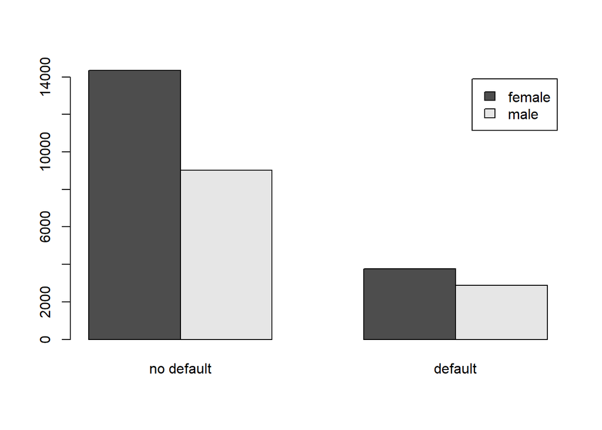

```r
barplot(tab, legend=T, beside=T, main='')
```

## 6.2 Tableau en proportions

On réalise le **tableau de contingence en proportions** :

Vous pouvez également obtenir les **proportions** (en pourcentage), en ligne ou en colonne dans votre tableau de contingence.

```r
prop.table(table(default_data$GENDER2, default_data$DEFAULT2))*100 # % totaux
```

```
##
##          no default   default
##   female  47.830000 12.543333
##   male    30.050000  9.576667
```

```r
prop.table(table(default_data$GENDER2, default_data$DEFAULT2), margin = 1)*100 # % en ligne
```

```
##
##          no default  default
##   female   79.22372 20.77628
##   male     75.83277 24.16723
```

```r
prop.table(table(default_data$GENDER2, default_data$DEFAULT2), margin = 2)*100 # % en colonne
```

```
##
##          no default  default
##   female   61.41500 56.70585
##   male     38.58500 43.29415
```

**Exemples d’interprétation :**

- Table 1 : 47.83% des individus de notre échantillon sont des femmes qui n’ont pas fait défaut. Les hommmes qui ont fait défaut représentent 9.58% des individus de notre échantillon.
- Table 2 : 24.17% des hommes ont fait défaut dans notre échantillon, contre 20.78% des femmmes.
- Table 3 : Parmi les personnes qui ont fait défaut, 56.71% sont des femmes, 43.29% sontt des hommmes.

**Quelle est la table qu’on privilégie pour avoir une idée du risque de défaut ?**

- Les tableaux 1 et 3 présentent la **structure de l’échantillon** et non le risque de défaut. Les proportions totales ou par colonne permettent surtout de décrire la composition de la population.
- Le tableau 2 met en évidence le **risque de défaut pour chaque groupe**. Les proportions par ligne sont à privilégier pour analyser le comportement des individus.

Vous pouvez vous entraîner en reproduisant cette démarche pour les autres tableaux de contingence (MARRIAGE et DEFAULT, EDUCATION et DEFAULT).

# 7 Estimation d’un modèle probit

On va utiliser la fonction **glm()** (“generalized linear model”) qui permet ensuite de spécifier plusieurs lois différentes pour les résidus. Les coefficients sont estimés avec la méthode du maximum de vraisemblance (qui utilise l’algorithme Fisher scoring ici).

On précise l’option “probit” comme suit :

```r
probit_model <- glm(DEFAULT ~ CREDIT + GENDER + EDUCATION + MARRIAGE + AGE + PAY_1 + PAY_2, family = binomial(link = "probit"), data = default_data)

summary(probit_model)
```

```
##
## Call:
## glm(formula = DEFAULT ~ CREDIT + GENDER + EDUCATION + MARRIAGE +
##     AGE + PAY_1 + PAY_2, family = binomial(link = "probit"),
##     data = default_data)
##
## Coefficients:
##                  Estimate    Std. Error z value             Pr(>|z|)
## (Intercept) -1.3657645153  0.1217231350 -11.220 < 0.0000000000000002 ***
## CREDIT      -0.0000017236  0.0000000763 -22.589 < 0.0000000000000002 ***
## GENDER1      0.1026783981  0.0168082082   6.109   0.0000000010036748 ***
## EDUCATION1   0.6844051094  0.0903967611   7.571   0.0000000000000370 ***
## EDUCATION2   0.7074405038  0.0899520769   7.865   0.0000000000000037 ***
## EDUCATION3   0.6903696747  0.0914473598   7.549   0.0000000000000437 ***
## MARRIAGE1    0.1396638997  0.0730841144   1.911               0.0560 .
## MARRIAGE2    0.0256898688  0.0737840369   0.348               0.7277
## AGE          0.0024391547  0.0010272106   2.375               0.0176 *
## PAY_1       -0.0000032478  0.0000007760  -4.185   0.0000284996641227 ***
## PAY_2       -0.0000035892  0.0000008045  -4.461   0.0000081430125041 ***
## ---
## Signif. codes:  0 '***' 0.001 '**' 0.01 '*' 0.05 '.' 0.1 ' ' 1
##
## (Dispersion parameter for binomial family taken to be 1)
##
##     Null deviance: 31705  on 29999  degrees of freedom
## Residual deviance: 30700  on 29989  degrees of freedom
## AIC: 30722
##
## Number of Fisher Scoring iterations: 5
```

Les coefficients sont en **probabilité** dans un modèle probit.

**Attention:** on interprète uniquement le signe et la significativité du coefficient, pas sa valeur.

**Interprétation :** pour une hausse d’une unité de la variable X, la probabilité de l’évènement augmente/diminue.

Ici, par exemple, quand le montant du crédit augmente d’un euros, la probabilité de faire défaut diminue. Cette corrélation semble hautement significative statistiquement. *Cela vous semble-t-il théoriquement correct ?*

**Performance du modèle :**

- La différence entre déviance résiduelle et déviance nulle correspond au gain expliqué par le modèle. Le modèle probit explique mieux que le modèle nul (sans variable explicative) : déviance résiduelle < déviance nulle.
- L’AIC (Akaike Information Criterion) est un indicateur de performance qui permet de comparer ce modèle à d’autres. Plus l’AIC est petit, plus le modèle est performant.
- Les itérations montrent que la convergence a été rapide.

# 8 Estimation d’un modèle logit

On précise l’option “logit” dans la fonction **glm()**.

```r
logit_model <- glm(DEFAULT ~ CREDIT + GENDER + EDUCATION + MARRIAGE + AGE + PAY_1 + PAY_2, family = binomial(link = "logit"), data = default_data)

summary(logit_model)
```

```
##
## Call:
## glm(formula = DEFAULT ~ CREDIT + GENDER + EDUCATION + MARRIAGE +
##     AGE + PAY_1 + PAY_2, family = binomial(link = "logit"), data = default_data)
##
## Coefficients:
##                  Estimate    Std. Error z value             Pr(>|z|)
## (Intercept) -2.3434434918  0.2303114075 -10.175 < 0.0000000000000002 ***
## CREDIT      -0.0000030578  0.0000001386 -22.069 < 0.0000000000000002 ***
## GENDER1      0.1743763196  0.0289324611   6.027    0.000000001670176 ***
## EDUCATION1   1.2712176598  0.1833889591   6.932    0.000000000004155 ***
## EDUCATION2   1.3067396032  0.1826658769   7.154    0.000000000000845 ***
## EDUCATION3   1.2748873425  0.1847845806   6.899    0.000000000005225 ***
## MARRIAGE1    0.2379342948  0.1247553714   1.907               0.0565 .
## MARRIAGE2    0.0365947594  0.1260356830   0.290               0.7715
## AGE          0.0039519969  0.0017545760   2.252               0.0243 *
## PAY_1       -0.0000081559  0.0000016613  -4.909    0.000000913756159 ***
## PAY_2       -0.0000080298  0.0000016562  -4.848    0.000001244226721 ***
## ---
## Signif. codes:  0 '***' 0.001 '**' 0.01 '*' 0.05 '.' 0.1 ' ' 1
##
## (Dispersion parameter for binomial family taken to be 1)
##
##     Null deviance: 31705  on 29999  degrees of freedom
## Residual deviance: 30673  on 29989  degrees of freedom
## AIC: 30695
##
## Number of Fisher Scoring iterations: 5
```

Les coefficients sont en forme **“log-odds”** dans un modèle logit.

**Attention:** on interprète uniquement le signe et la significativité du coefficient, pas sa valeur.

**Interprétation :** pour une hausse d’une unité de la variable X, les log odds de l’évènement (par rapport à son contraire) augmentent/diminuent.

Ici, par exemple, quand l’âge augmente d’une année, les log odds du défaut (par rapport au non-défaut) augmentent. Cette corrélation est significative statistiquement au seuil de 5%.

# 9 Coefficients en “odds”

**Rappel:** l’odds d’un évènement est le rapport du nombre d’individus présentant l’événement considéré sur le nombre d’individus ne le présentant pas. Autrement dit, c’est le rapport de probabilité d’un événement sur la probabilité de son non-événement.

L’odds correspond à l’exponentielle des log odds. Ils vont de 0 à l’infini (contrairement à une probabilité qui va de 0 à 1).

Pour calculer les “odds”, on peut **appliquer l’exponentielle** aux coefficients log odds.

```r
cbind(Estimate = round(coef(logit_model), 5), OD = round(exp(coef(logit_model)), 5))
```

```
##             Estimate      OD
## (Intercept) -2.34344 0.09600
## CREDIT       0.00000 1.00000
## GENDER1      0.17438 1.19050
## EDUCATION1   1.27122 3.56519
## EDUCATION2   1.30674 3.69411
## EDUCATION3   1.27489 3.57830
## MARRIAGE1    0.23793 1.26863
## MARRIAGE2    0.03659 1.03727
## AGE          0.00395 1.00396
## PAY_1       -0.00001 0.99999
## PAY_2       -0.00001 0.99999
```

Pour avoir directement les odds, on a besoin du **package “mfx”** qu’on a préalablement installé et chargé et la fonction **logitor()**.

```r
logit_OD <- logitor(DEFAULT~CREDIT + GENDER + EDUCATION + MARRIAGE + AGE + PAY_1 + PAY_2, data = default_data)

logit_OD
```

```
## Call:
## logitor(formula = DEFAULT ~ CREDIT + GENDER + EDUCATION + MARRIAGE +
##     AGE + PAY_1 + PAY_2, data = default_data)
##
## Odds Ratio:
##                OddsRatio     Std. Err.        z                 P>|z|
## CREDIT     0.99999694224 0.00000013855 -22.0690 < 0.00000000000000022 ***
## GENDER1    1.19050349132 0.03444419594   6.0270    0.0000000016701756 ***
## EDUCATION1 3.56519111041 0.65381668664   6.9318    0.0000000000041549 ***
## EDUCATION2 3.69410979246 0.67478780459   7.1537    0.0000000000008446 ***
## EDUCATION3 3.57829826512 0.66121434421   6.8993    0.0000000000052253 ***
## MARRIAGE1  1.26862583480 0.15826788720   1.9072               0.05649 .
## MARRIAGE2  1.03727259069 0.13073335945   0.2904               0.77155
## AGE        1.00395981633 0.00176152377   2.2524               0.02430 *
## PAY_1      0.99999184418 0.00000166127  -4.9094    0.0000009137561588 ***
## PAY_2      0.99999197021 0.00000165615  -4.8485    0.0000012442267210 ***
## ---
## Signif. codes:  0 '***' 0.001 '**' 0.01 '*' 0.05 '.' 0.1 ' ' 1
```

**Interprétation :**

- odd ratio > 1 → risque de défaut plus élevé.
- odd ratio < 1 → risque de défaut plus faible.
- odd ratio = 1 → pas d’effet

# 10 Effets marginaux en probabilité

On utilise la fonction **logitmfx()** pour avoir les **effets marginaux** (changement dans la *probabilité* quand la variable explicative change d’une unité) à partir du modèle logit.

```r
logit_me <- logitmfx(DEFAULT ~ CREDIT + GENDER + EDUCATION + MARRIAGE + AGE + PAY_1 + PAY_2, data = default_data)

logit_me
```

```
## Call:
## logitmfx(formula = DEFAULT ~ CREDIT + GENDER + EDUCATION + MARRIAGE +
##     AGE + PAY_1 + PAY_2, data = default_data)
##
## Marginal Effects:
##                      dF/dx       Std. Err.        z                 P>|z|
## CREDIT     -0.000000505437  0.000000022465 -22.4990 < 0.00000000000000022 ***
## GENDER1     0.029127176458  0.004879615628   5.9692     0.000000002384871 ***
## EDUCATION1  0.231206118139  0.035674181217   6.4810     0.000000000091087 ***
## EDUCATION2  0.220853284492  0.031229234891   7.0720     0.000000000001527 ***
## EDUCATION3  0.257556631340  0.042215957756   6.1009     0.000000001054526 ***
## MARRIAGE1   0.039573303373  0.020874539760   1.8958               0.05799 .
## MARRIAGE2   0.006044840912  0.020804712070   0.2906               0.77139
## AGE         0.000653250455  0.000290000280   2.2526               0.02429 *
## PAY_1      -0.000001348133  0.000000273554  -4.9282     0.000000829822628 ***
## PAY_2      -0.000001327301  0.000000272910  -4.8635     0.000001153241415 ***
## ---
## Signif. codes:  0 '***' 0.001 '**' 0.01 '*' 0.05 '.' 0.1 ' ' 1
##
## dF/dx is for discrete change for the following variables:
##
## [1] "GENDER1"    "EDUCATION1" "EDUCATION2" "EDUCATION3" "MARRIAGE1"
## [6] "MARRIAGE2"
```

**Interprétation :**

Les effets marginaux sont toujours en unités de probabilité, sur l’échelle [0;1]. Pour rendre l’interprétation plus intuitive, on peut multiplier les coefficients par 100 pour lire l’effet marginal en points de pourcentage (que ce soit pour les variables binaires ou continues).

Exemple : Si **GENDER** passe de 0 à 1 (femme → homme), la probabilité de défaut augmente de 0.0291 sur l’échelle [0;1]. Autrement dit, les hommes ont une probabilité de défaut supérieure de 2.91 points de pourcentage par rapport aux femmes.

Pour les **effets marginaux estimés à partir du modèle probit**, on fait :

```r
summary(margins(probit_model))  # calcule directement les effets marginaux
```

```
##      factor     AME     SE        z      p   lower   upper
##         AGE  0.0007 0.0003   2.3751 0.0175  0.0001  0.0013
##      CREDIT -0.0000 0.0000 -22.7071 0.0000 -0.0000 -0.0000
##  EDUCATION1  0.1448 0.0130  11.1125 0.0000  0.1193  0.1703
##  EDUCATION2  0.1515 0.0128  11.8287 0.0000  0.1264  0.1766
##  EDUCATION3  0.1465 0.0137  10.7216 0.0000  0.1197  0.1733
##     GENDER1  0.0298 0.0049   6.0650 0.0000  0.0202  0.0394
##   MARRIAGE1  0.0400 0.0199   2.0116 0.0443  0.0010  0.0789
##   MARRIAGE2  0.0070 0.0200   0.3516 0.7252 -0.0322  0.0463
##       PAY_1 -0.0000 0.0000  -4.1853 0.0000 -0.0000 -0.0000
##       PAY_2 -0.0000 0.0000  -4.4621 0.0000 -0.0000 -0.0000
```

# 11 Probabilité prédite de faire défaut

Prédire la probabilité de faire défaut pour un individu présentant les caractéristiques suivantes : homme de 55 ans, marié, diplômé de l’université, montant de 50 000 euros de crédit, a dépensé 2000 euros dans les 2 derniers mois.

La fonction **predict()** permet de faire cela pour un “generalized linear model”.

On commence par **construire les données** correspondantes :

```r
indiv1 <- data.frame(CREDIT = 50000, GENDER = 1, EDUCATION = 2, MARRIAGE = 1, AGE = 55, PAY_1 = 2000, PAY_2 = 2000)
indiv1$GENDER <- as.factor(indiv1$GENDER)
indiv1$EDUCATION <- as.factor(indiv1$EDUCATION)
indiv1$MARRIAGE <- as.factor(indiv1$MARRIAGE)
```

Puis on **prédit la probabilité** associée :

```r
prob_logit <- predict(logit_model, newdata = indiv1, type = "response")
prob_logit
```

```
##         1
## 0.3561089
```

La probabilité de faire défaut pour un homme de 55 ans, marié, diplômé de l’université, avec 50 000 euros de crédit et qui a dépensé 2000 euros dans les 2 derniers mois est de 35.61%.

Idem pour le **probit** :

```r
prob_probit <- predict(probit_model, newdata = indiv1, type = "response")
prob_probit
```

```
##         1
## 0.3513478
```

Comparez les résultats.

# 12 Tester le pouvoir explicatif du modèle

Test à partir du **ratio de vraisemblance** :

Mon modèle avec diverses variables explicatives a-t-il un plus grand pouvoir explicatif que le modèle nul (c’est-à-dire, simplement modélisé par la constante) ?

**H0 :** le modèle nul est plus explicatif.

La commande suivante nous donne la p-value du test :

```r
with(logit_model, pchisq(null.deviance - deviance, df.null - df.residual, lower.tail = FALSE))
```

```
## [1] 0.000000000000000000000000000000000000000000000000000000000000…
```

On rejette H0, notre modèle logit a un plus grand pouvoir explicatif que le modèle nul.

```r
with(probit_model, pchisq(null.deviance - deviance, df.null - df.residual, lower.tail = FALSE))
```

```
## [1] 0.000000000000000000000000000000000000000000000000000000000000…
```

On rejette H0, notre modèle probit a un plus grand pouvoir explicatif que le modèle nul.

**Quel modèle, entre le probit et le logit, est plus performant ?**

```r
AIC(logit_model, probit_model)
```

```
##              df      AIC
## logit_model  11 30694.65
## probit_model 11 30721.50
```

Ou encore, avec le BIC :

```r
BIC(logit_model, probit_model)
```

```
##              df      BIC
## logit_model  11 30786.05
## probit_model 11 30812.90
```

**Règle générale :** plus le AIC et le BIC sont petits → meilleur est l’ajustement du modèle.

Ici : AIC logit < AIC probit → logit est légèrement préféré en termes d’ajustement global.

# 13 Linear Probability Model

```r
default_data$DEFAULT_num <- as.numeric(default_data$DEFAULT) # pour un linear model, on a besoin que la variable dépendante soit numérique

lpm_model <- lm(DEFAULT_num ~ CREDIT + GENDER + EDUCATION + MARRIAGE + AGE + PAY_1 + PAY_2,
                data = default_data)

summary(lpm_model)
```

```
##
## Call:
## lm(formula = DEFAULT_num ~ CREDIT + GENDER + EDUCATION + MARRIAGE +
##     AGE + PAY_1 + PAY_2, data = default_data)
##
## Residuals:
##      Min       1Q   Median       3Q      Max
## -0.36101 -0.25671 -0.19907 -0.06357  1.17755
##
## Coefficients:
##                  Estimate    Std. Error t value             Pr(>|t|)
## (Intercept)  1.1048495211  0.0307297657  35.954 < 0.0000000000000002 ***
## CREDIT      -0.0000004720  0.0000000200 -23.599 < 0.0000000000000002 ***
## GENDER1      0.0306504706  0.0048690304   6.295  0.00000000031168163 ***
## EDUCATION1   0.1410794317  0.0193463326   7.292  0.00000000000031222 ***
## EDUCATION2   0.1493266535  0.0192268520   7.767  0.00000000000000832 ***
## EDUCATION3   0.1457479152  0.0198510152   7.342  0.00000000000021563 ***
## MARRIAGE1    0.0373547087  0.0214256594   1.743             0.081264 .
## MARRIAGE2    0.0050793413  0.0216078324   0.235             0.814156
## AGE          0.0007170492  0.0003010890   2.382             0.017248 *
## PAY_1       -0.0000004665  0.0000001395  -3.344             0.000826 ***
## PAY_2       -0.0000006129  0.0000001565  -3.916  0.00009010299754361 ***
## ---
## Signif. codes:  0 '***' 0.001 '**' 0.01 '*' 0.05 '.' 0.1 ' ' 1
##
## Residual standard error: 0.4088 on 29989 degrees of freedom
## Multiple R-squared:  0.03031,    Adjusted R-squared:  0.02999
## F-statistic: 93.75 on 10 and 29989 DF,  p-value: < 0.00000000000000022
```

**Avantage du LPM :** il estime directement des effets marginaux. **Désavantage :** il peut générer des probabilités impossibles (<0 ou >1), souffre d’hétéroscédasticité, et les inférences statistiques (p‑values, intervalles) sont moins fiables que dans les modèles logit ou probit.

**Comparer ajustement des différents modèles** (LPM, logit, probit)

```r
AIC(lpm_model, logit_model, probit_model)
```

```
##              df      AIC
## lpm_model    12 31476.17
## logit_model  11 30694.65
## probit_model 11 30721.50
```

L’ajustement du LPM est bien moins bon que l’ajustement des modèles logit et probit.

**Prédire la probabilité de défaut pour un profil**

```r
predict(lpm_model, indiv1, type = "response")      # LPM
```

```
##        1
## 1.335859
```

```r
predict(logit_model, indiv1, type = "response")   # Logit
```

```
##         1
## 0.3561089
```

```r
predict(probit_model, indiv1, type = "response")  # Probit
```

```
##         1
## 0.3513478
```

La probabilité estimée par le LPM dépasse 1, ce qui montre une limite pratique.

**BONUS : visualiser les différences**

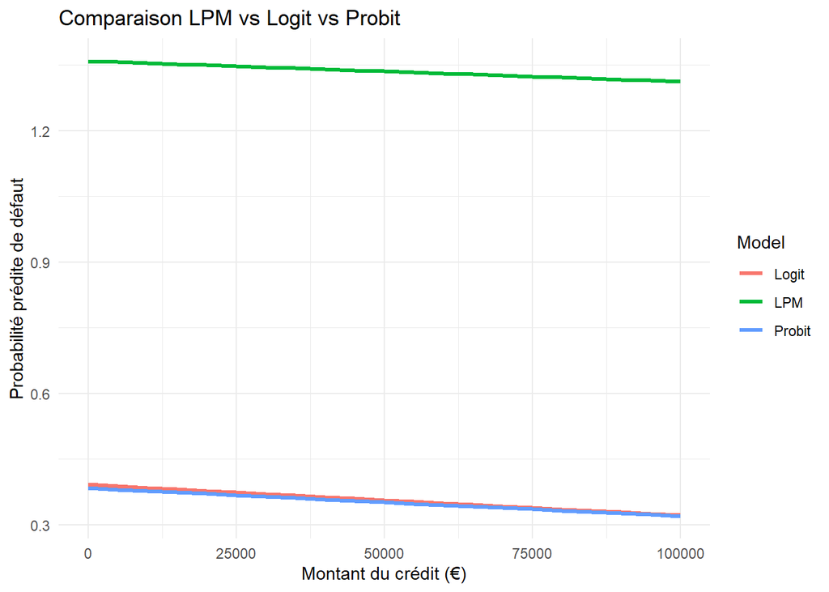

```r
library(ggplot2)
library(tidyr)

# Prévoir pour différentes valeurs de CREDIT
credit_seq <- seq(0, 100000, by = 5000)

df_plot <- data.frame(
  CREDIT = credit_seq,
  GENDER = factor(1),
  EDUCATION = factor(2),
  MARRIAGE = factor(1),
  AGE = 55,
  PAY_1 = 2000,
  PAY_2 = 2000
)

df_plot$LPM <- predict(lpm_model, df_plot)
df_plot$Logit <- predict(logit_model, df_plot, type = "response")
df_plot$Probit <- predict(probit_model, df_plot, type = "response")

# Mettre en format long pour ggplot
df_long <- pivot_longer(df_plot, cols = c("LPM","Logit","Probit"), names_to = "Model", values_to = "Prob")

ggplot(df_long, aes(x = CREDIT, y = Prob, color = Model)) +
  geom_line(size = 1.2) +
  labs(title = "Comparaison LPM vs Logit vs Probit",
       x = "Montant du crédit (€)",
       y = "Probabilité prédite de défaut") +
  theme_minimal()
```